# Creating Publication-Quality Graphics with ggplot2

2021-06-16

### Workshop Overview

**Teaching**: 60 minutes  
**Exercises**: 20 minutes

**Guiding Questions**:

What are the components of a ggplot?  
How do I create scatterplots, boxplots, and barplots?  
How can I change the aesthetics (ex. colour, transparency) of my plot?  
How can I create multiple plots at once?

**Lesson Objectives**:

Produce scatter plots, boxplots, and barplots using ggplot.  
Set universal plot settings.  
Describe what faceting is and apply faceting in ggplot.  
Modify the aesthetics of an existing ggplot plot (including axis labels and colour).  
Build complex and customized plots from data in a data frame.

We start by loading the required package. **`ggplot2`** is also included in the **`tidyverse`** package.

```r
library(tidyverse)
```

If not still in the workspace, load the data we saved in the previous lesson.

```r
gapminder <- read_csv(
  here::here("data", "gapminder_data.csv")
)
```

# Warm-up

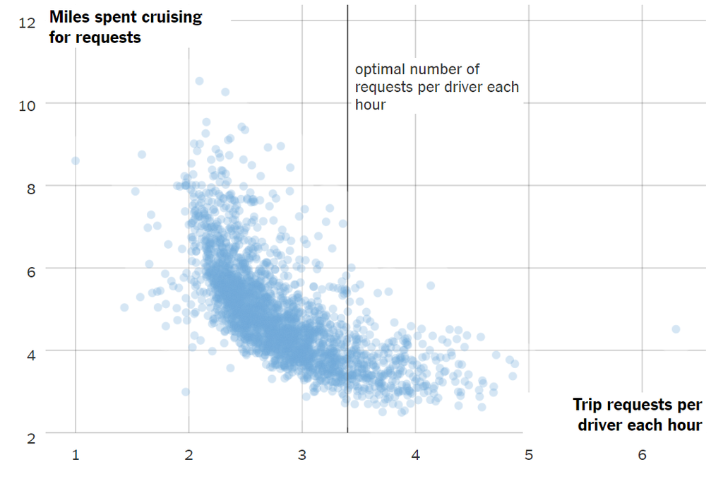

# Describe the qualities of this plot.

# Data Visualization using **`ggplot2`**

**`ggplot2`** is a plotting package that makes it simple to create complex plots from data in a data frame. It provides a more programmatic interface for specifying what variables to plot, how they are displayed, and general visual properties. Therefore, we only need minimal changes if the underlying data change or if we decide to change from a bar plot to a scatter plot. This helps in creating publication quality plots with minimal amounts of adjustments and tweaking.

Packages in `R` are basically sets of additional functions that let you do more stuff. The functions we’ve been using so far, like `str()` or `mean()`, come built into `R`; packages give you access to more of them. Before you use a package for the first time you need to install it on your machine, and then you should import it in every subsequent `R` session when you need it. You should already have installed the **`tidyverse`** package. This is an “umbrella-package” that installs several packages useful for data analysis which work together well such as **`tidyr`**, **`dplyr`**, **`ggplot2`**, **`readr`**, **`forcats`**, etc.

The **`tidyverse`** package tries to address common issues that arise when doing data analysis with some of the functions that come with `R`.

1. The `tidyverse` solves complex problems by combining many simple pieces.

> No matter how complex and polished the individual operations are, it is often the quality of the glue that most directly determines the power of the system. - Hal Abelson
2. The `tidyverse` is written for people to read!

> Computer efficiency is a secondary concern because the bottleneck in most data analysis is thinking time, not computing time. - Hadley Wickham

If we haven’t already done so, we can type `install.packages("tidyverse")` straight into the console. In fact, it’s better to write this in the console than in our script for any package, as there’s no need to re-install packages every time we run the script.

Then, to load the package type:

```r
## load the tidyverse packages
library(tidyverse)
```

To learn more about **`ggplot2`** after the workshop, you may want to check out this [**`ggplot2`** reference website (link)](https://ggplot2.tidyverse.org/reference/) and this [handy cheatsheet on **`ggplot2`** (link)](https://github.com/rstudio/cheatsheets/raw/master/data-visualization-2.1.pdf).

## gapminder data

We’ll read in the `gapminder` data from yesterday using the `read_csv()` function and the `here()` function.

```r
gapminder <- read_csv(
  here::here("data", "gapminder_data.csv")
)
```

## Plotting with **`ggplot2`**

`ggplot2` functions like data in the ‘long’ format, i.e., a column for every dimension, and a row for every observation. There are other data formats, which we will discuss in the *Data Wrangling in `R`* workshop, as well as how to covert from one data format to another. Well-structured data will save you lots of time when making figures with `ggplot2` and when working in `R`!

`ggplot()` graphics are built step by step by adding new elements. Adding layers in this fashion allows for extensive flexibility and customization of plots.

To build a `ggplot()`, we will use the following basic template that can be used for different types of plots:

```
ggplot(data = <DATA>, mapping = aes(<VARIABLE MAPPINGS>)) +
<GEOM_FUNCTION>()
```

Let’s go through this step by step!

1. Use the `ggplot()` function and bind the plot to a specific data frame using the `data` argument

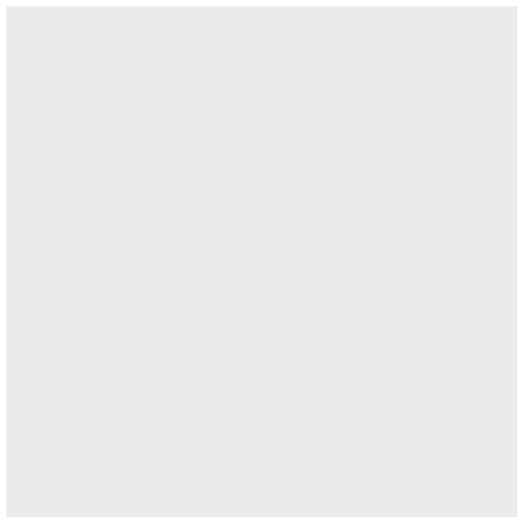

```r
ggplot(data = gapminder)
```

```r
## Creates a blank ggplot(), referencing the gapminder dataset
```

2. Define a mapping (using the aesthetic (`aes`) function), by selecting the variables to be plotted and specifying how to present them in the graph, e.g. as x/y positions or characteristics such as size, shape, color, etc.

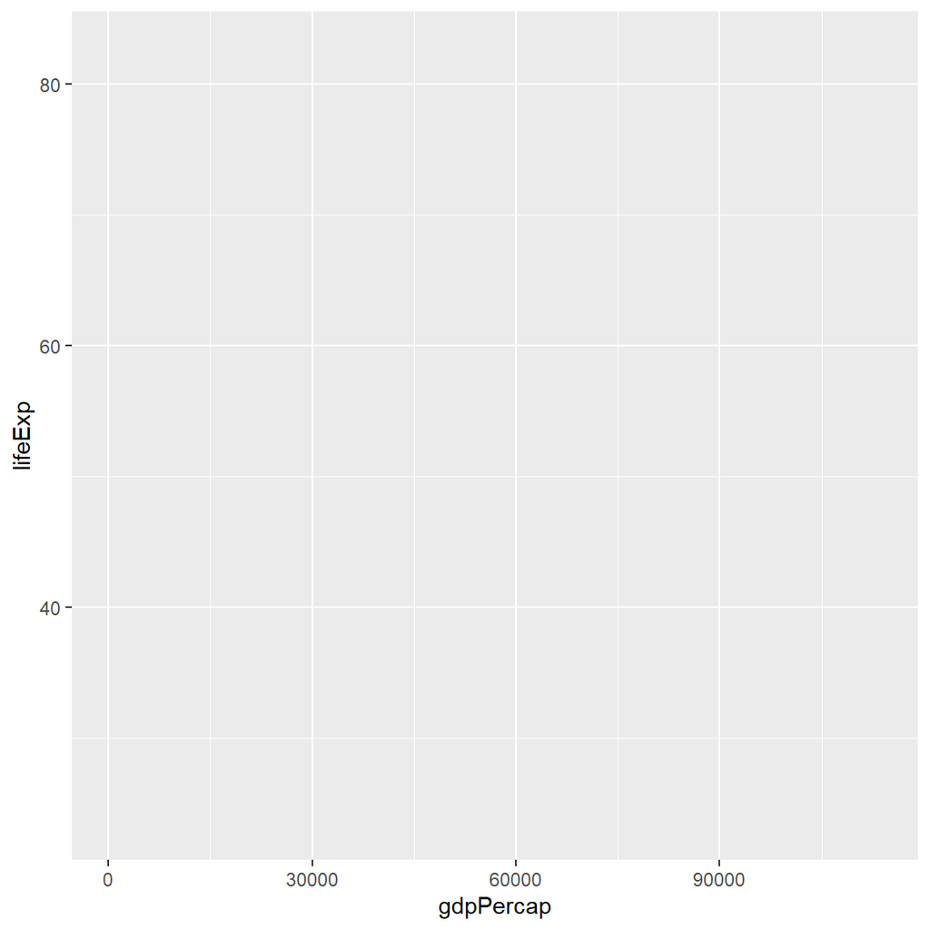

```r
ggplot(data = gapminder,
       mapping = aes(x = gdpPercap, y = lifeExp))
```

```r
## Creates a blank ggplot(), with the variables mapped to the x- and y-axis
## ggplot() knows where the variables live, since you have defined the data to use
```

3. Add ‘geoms’ – graphical representations of the data in the plot (points, lines, bars). **`ggplot2`** offers many different geoms; we will use some common ones today, including:
   - `geom_point()` for scatter plots
   - `geom_boxplot()` for boxplots
   - `geom_bar()` for bar charts
   - `geom_line()` for trend lines, time series, etc.

Because we have two continuous variables in the data, let’s use `geom_point()` first:

```r
ggplot(data = gapminder,
       mapping = aes(x = gdpPercap, y = lifeExp)) +
  geom_point()
```

[output not shown]

```r
 ## Adds a point for each row (observation) in the data
```

You can think of the `+` sign as adding layers to the plot. Each `+` sign must be placed at the end of the line containing the *previous* layer. If, instead, the `+` sign is added at the beginning of the line containing the new layer, **`ggplot2`** will not add the new layer and will return an error message.

```r
# This is the correct syntax for adding layers
ggplot(data = gapminder,
       mapping = aes(x = gdpPercap, y = lifeExp)) +
  geom_point()
```

[output not shown]

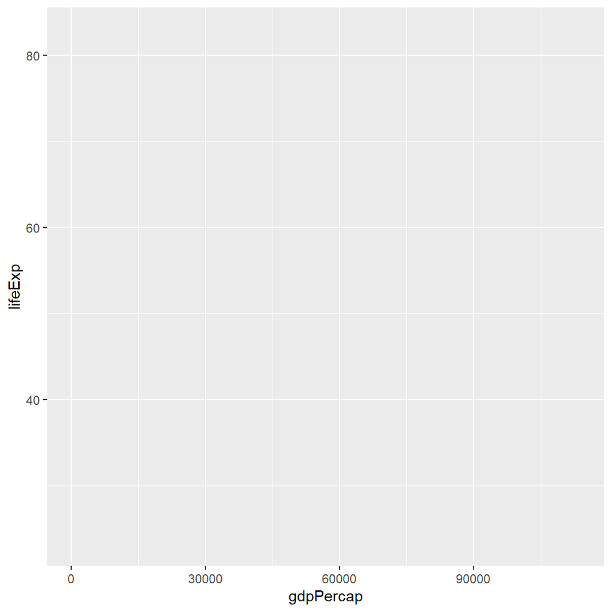

```r
# This will not add the new layer and will return an error message
ggplot(data = gapminder,
       mapping = aes(x = gdpPercap, y = lifeExp))
```

```r
+ geom_point()
```

```
Error: Cannot use `+.gg()` with a single argument. Did you accidentally put + on a new line?
```

## Building Plots Iteratively

Building plots with **`ggplot2`** is typically an iterative process. We start by defining the dataset we’ll use, lay out the axes, and choose a geom:

```r
ggplot(data = gapminder,
       mapping = aes(x = gdpPercap, y = lifeExp)) +
  geom_point()
```

[output not shown]

Then, we start modifying this plot to extract more information from it. For instance, we can add transparency (`alpha`) to the points, to avoid overplotting:

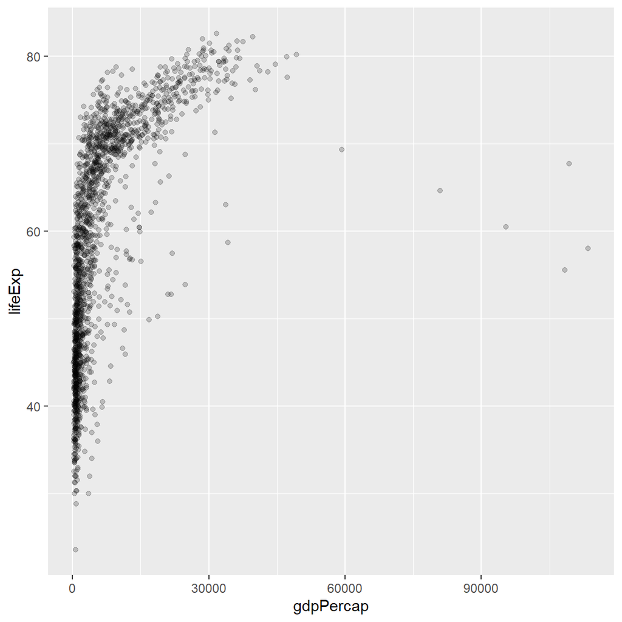

```r
ggplot(data = gapminder,
       mapping = aes(x = gdpPercap, y = lifeExp)) +
  geom_point(alpha = 0.2)
```

```r
    ## alpha reduces the opacity of the points
    ## 0 is fully transparent
    ## 1 is the original opacity
```

We can also add colors for all the points:

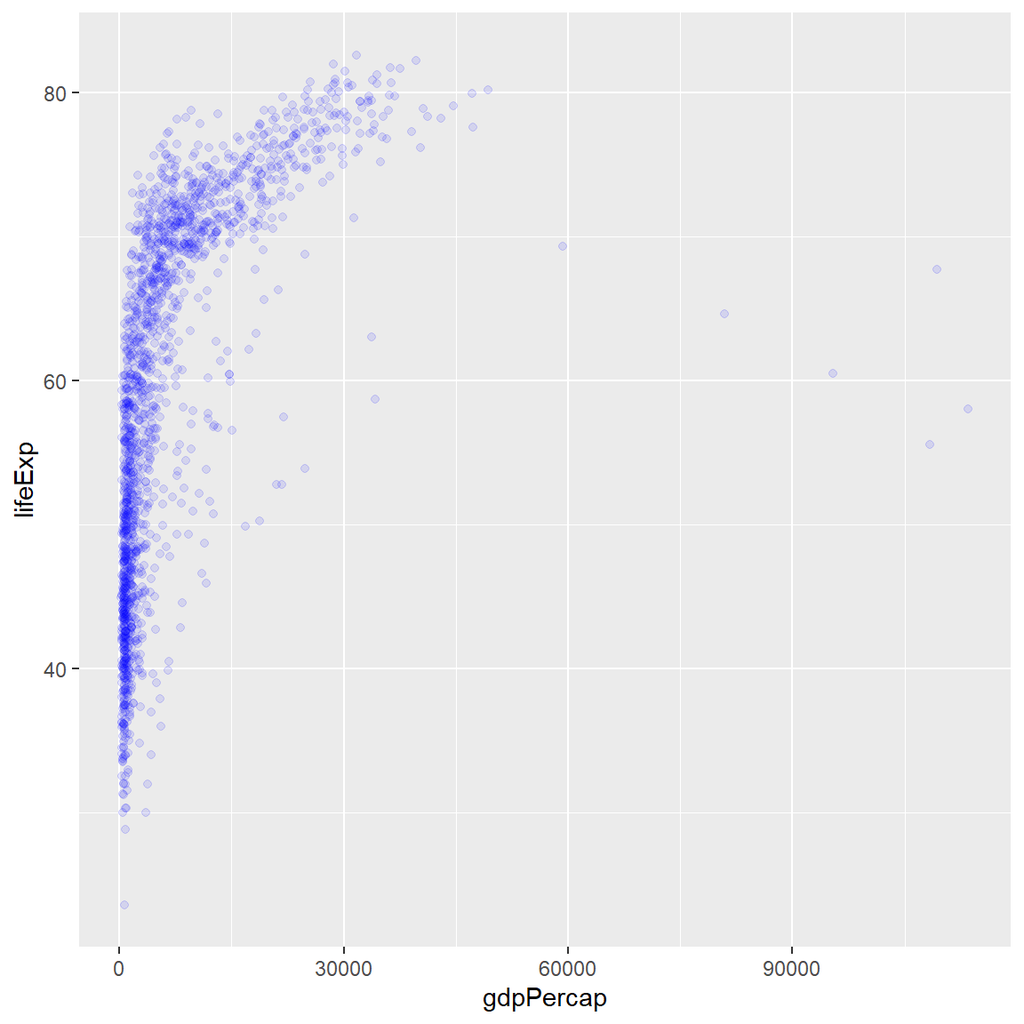

```r
ggplot(data = gapminder,
       mapping = aes(x = gdpPercap, y = lifeExp)) +
  geom_point(alpha = 0.1, color = "blue")
```

## Challenge 1

`geom_point` also accepts aesthetics of size and shape. The size of a point is its width in mm. The shape of a point has five different options for plotting:

- an integer [0, 25] of defined plotting characters – same as base `R`
- the name of the shape in quotations (e.g. “circle open” or “diamond filled”)
- a single character, to use that character as a plotting symbol
- a “.” to draw the smallest point that is visible – typically 1 pixel
- an NA, to draw nothing

Reference for shapes in integers and characters:  
https://ggplot2.tidyverse.org/articles/ggplot2-specs.html

> Modify the previous code chunk to assign one of these aesthetics to the `geom_point` aspect of your plot. What happened?

```r
## Your ggplot code to answer the challenge goes here!
```

## Assigning More Variables to Aesthetics

To color each continent in the plot differently, you could use a vector as an input to the argument **color**. **`ggplot2`** will provide a different color corresponding to different values in the vector. Here is an example where we color with **`continent`**:

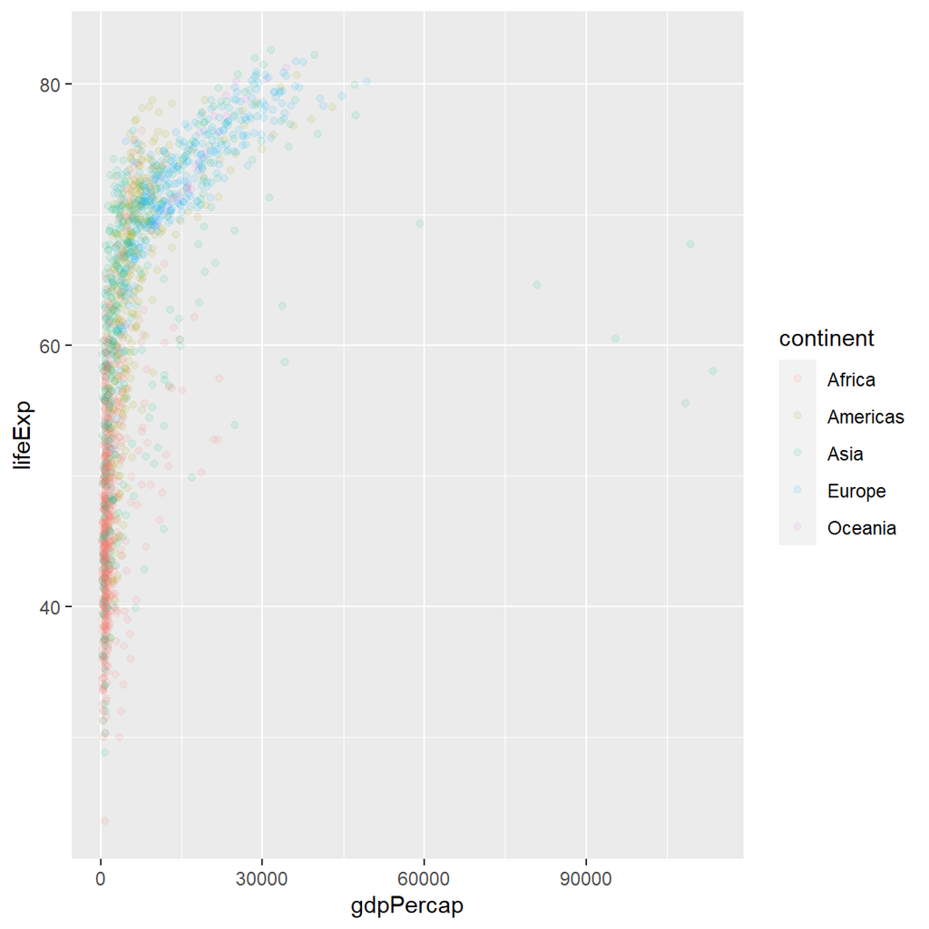

```r
ggplot(data = gapminder,
       mapping = aes(x = gdpPercap, y = lifeExp)) +
  geom_point(alpha = 0.1,  aes(color = continent))
```

**Note:** When specifying an `alpha` for a scatterplot, it automatically uses that **same** `alpha` in the legend. To remedy this you can add:

```
guides(colour = guide_legend(override.aes = list(alpha = 1)))
```

to your plot. This customizes the legend appearance, similar to what we will see in the customization section.

We can also specify the colors directly inside the mapping provided in the `ggplot()` function. This will be seen by **any** geom layers and the mapping will be determined by the x- and y-axis set up in `aes()`.

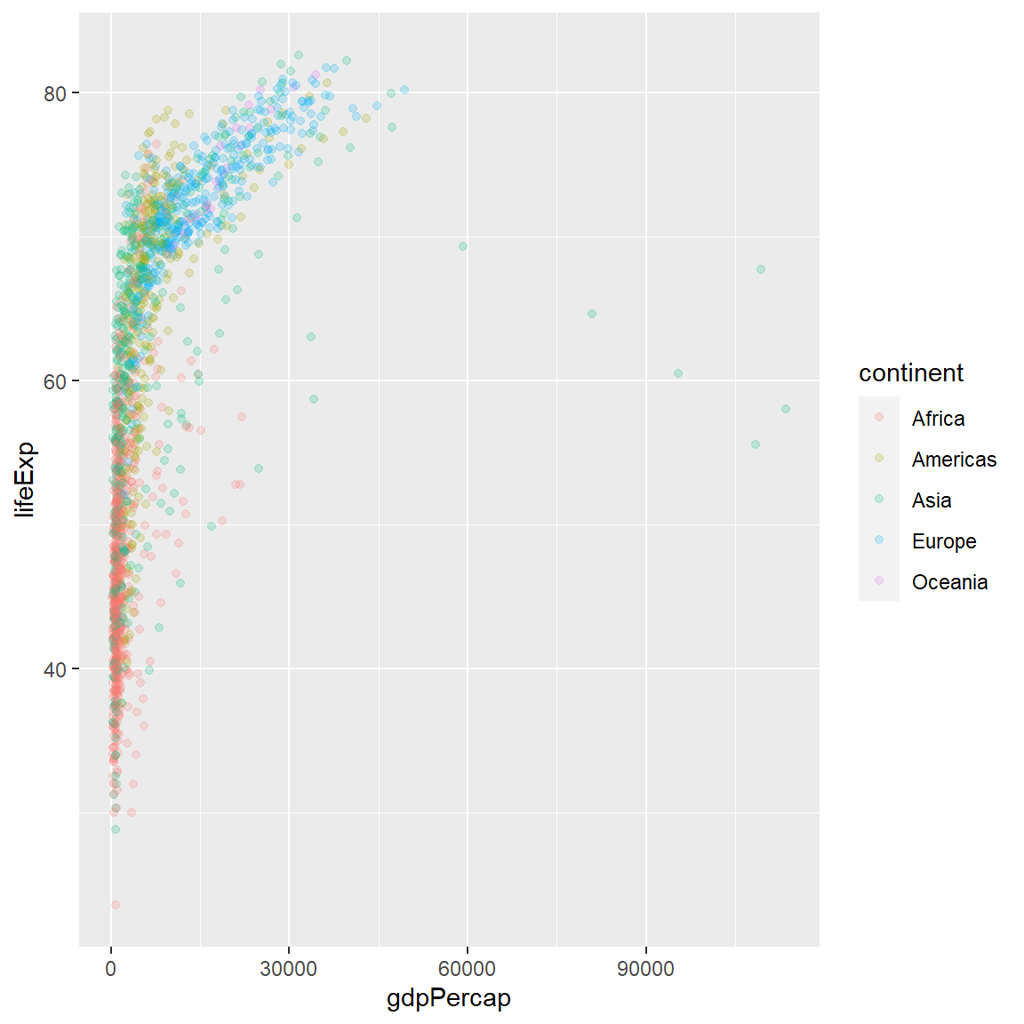

```r
ggplot(data = gapminder,
       mapping = aes(x = gdpPercap, y = lifeExp, color = continent)) +
  geom_point(alpha = 0.2)
```

Notice that we can change the geom layer and colors will be still determined by **`continent`**

### Local Aesthetics versus Global Aesthetics

When you define aesthetics in the `ggplot()` function, those mappings hold for **every** aspect of your plot.

For example, if you chose to add a trend line to your plot of GDP per cap versus life expectancy, you would get different lines depending on where you define your color aesthetics.

**Globally**

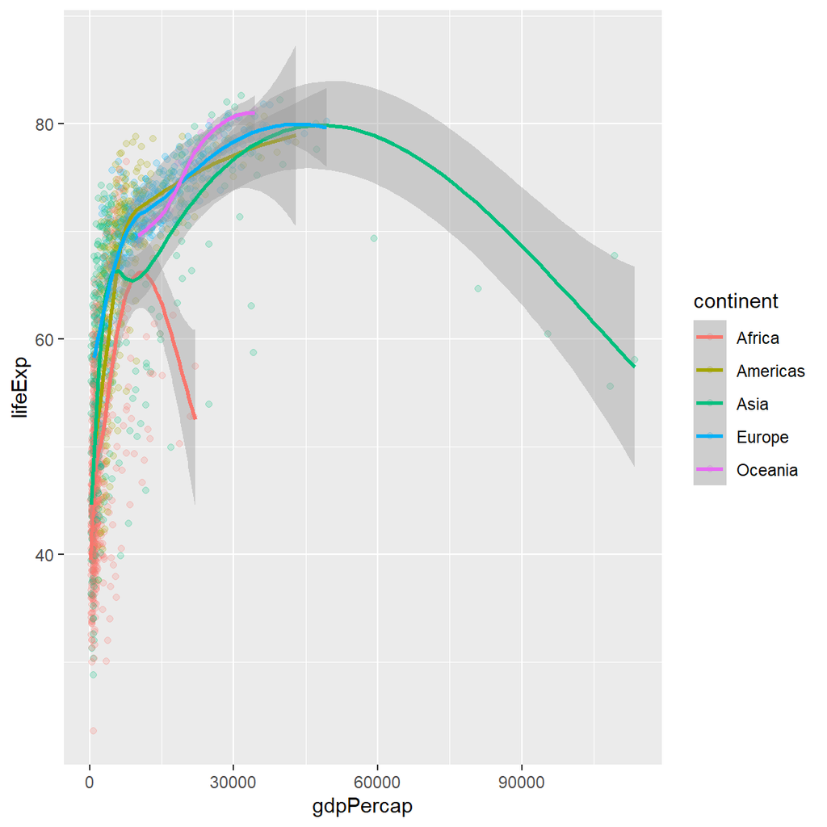

```r
ggplot(data = gapminder,
       mapping = aes(x = gdpPercap, y = lifeExp, color = continent)) +
  geom_point(alpha = 0.2) +
  geom_smooth()
```

```r
  ## trend line for each continent -- because color is defined globally
```

**Locally**

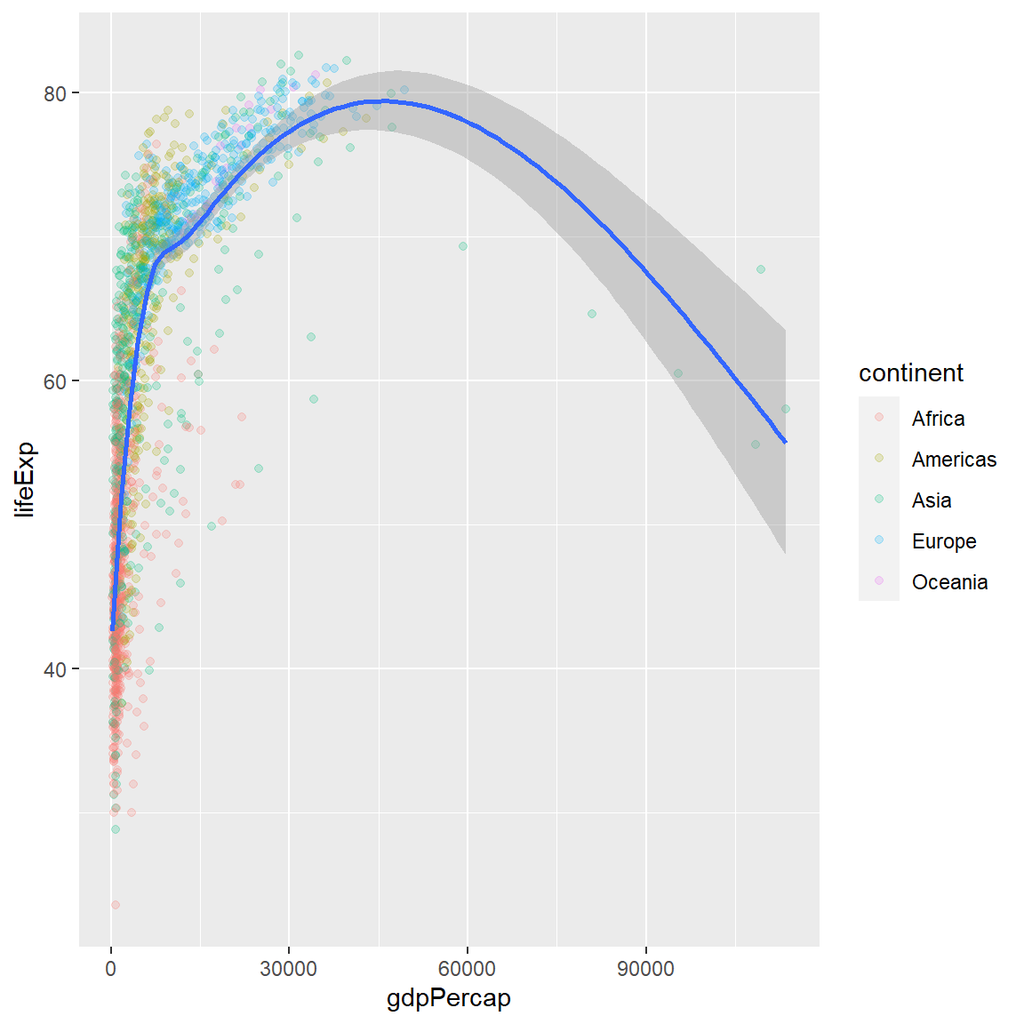

```r
ggplot(data = gapminder,
       mapping = aes(x = gdpPercap, y = lifeExp)) +
  geom_point(alpha = 0.2, aes(color = continent)) +
  geom_smooth()
```

```r
  ## one trend line -- no color defined globally
```

### Challenge 2

> Part 1: Inspect the `geom_point` help file to see what other aesthetics are available. Map a new variable from the dataset to another aesthetic in your plot. What happened? Does the aesthetic change if you use a continuous variable versus a categorical/discrete variable?

```r
## Your ggplot() code for the challenge goes here!
```

> Part 2: Use what you just learned to create a scatter plot of `lifeExp` over time with data from different continents being showed in different colors. Is this a good way to show this type of data?

```r
## Your ggplot() code for the challenge goes here!
```

### Layers

Using a scatterplot probably isn’t the best for visualizing change over time. Instead, let’s tell `ggplot` to visualize the data as a line plot:

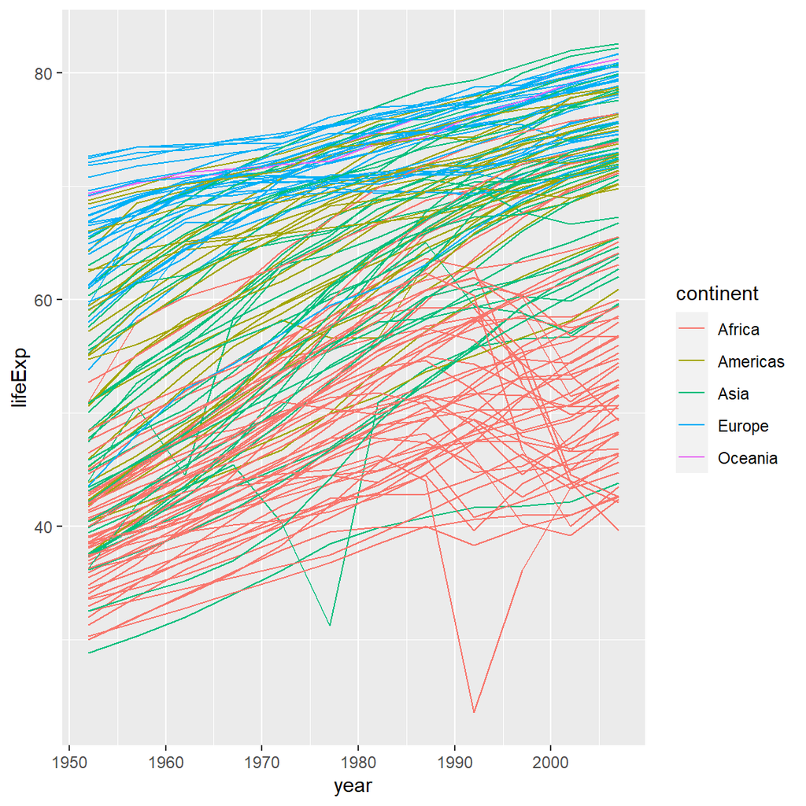

```r
ggplot(data = gapminder,
       mapping = aes(x = year, y = lifeExp, group = country, color = continent)) +
  geom_line()
```

Instead of adding a `geom_point()` layer, we’ve added a `geom_line()` layer. We’ve added the **group** *aesthetic*, which tells `ggplot` to draw a line for each country. Without the `group` aesthetic, our plot would look something like:

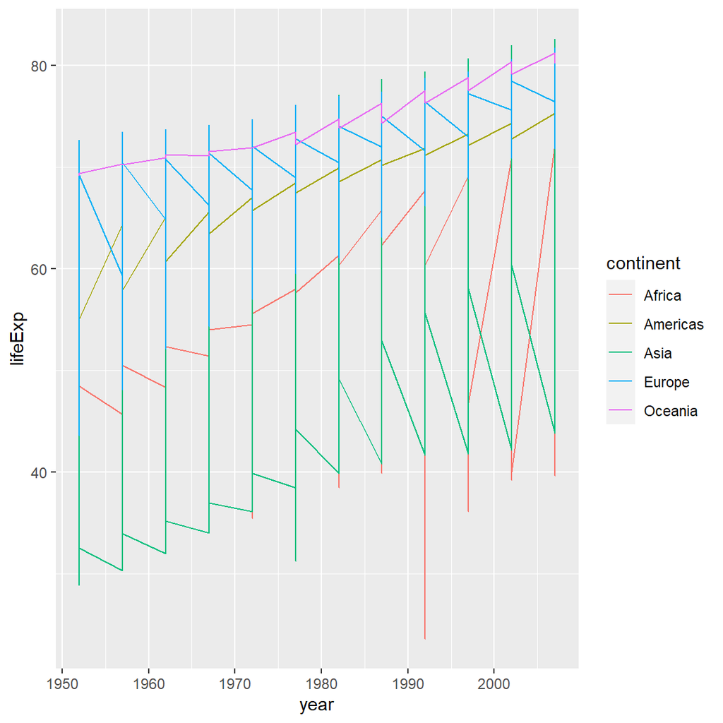

```r
ggplot(data = gapminder,
       mapping = aes(x = year, y = lifeExp, color = continent)) +
  geom_line()
```

### Multiple geoms

But what if we want to visualize both lines and points on the plot? We can add another layer to our line plot!

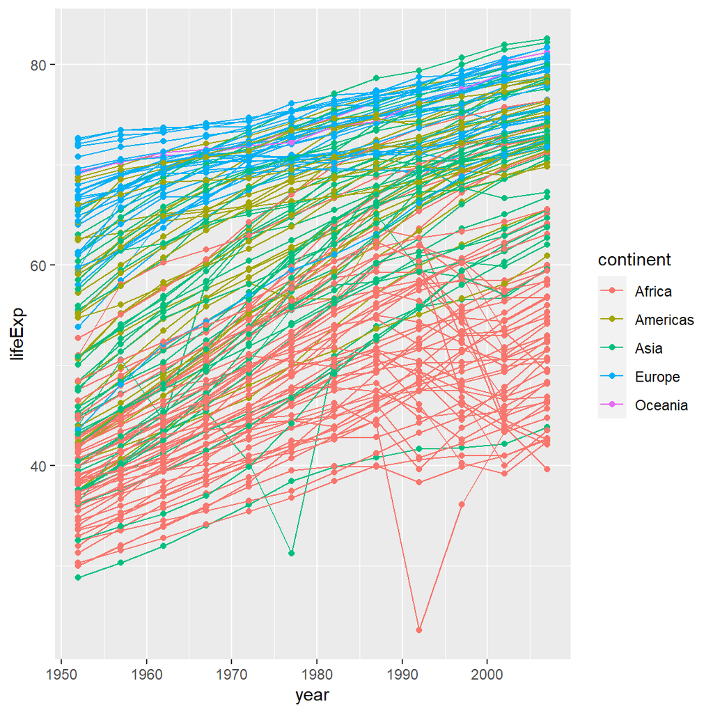

```r
ggplot(data = gapminder,
       mapping = aes(x = year, y = lifeExp, group = country, color = continent)) +
  geom_line() +
  geom_point()
```

It’s important to note that each layer is drawn on top of the previous layer. In this example, the points have been drawn *on top of* the lines. Here’s a demonstration:

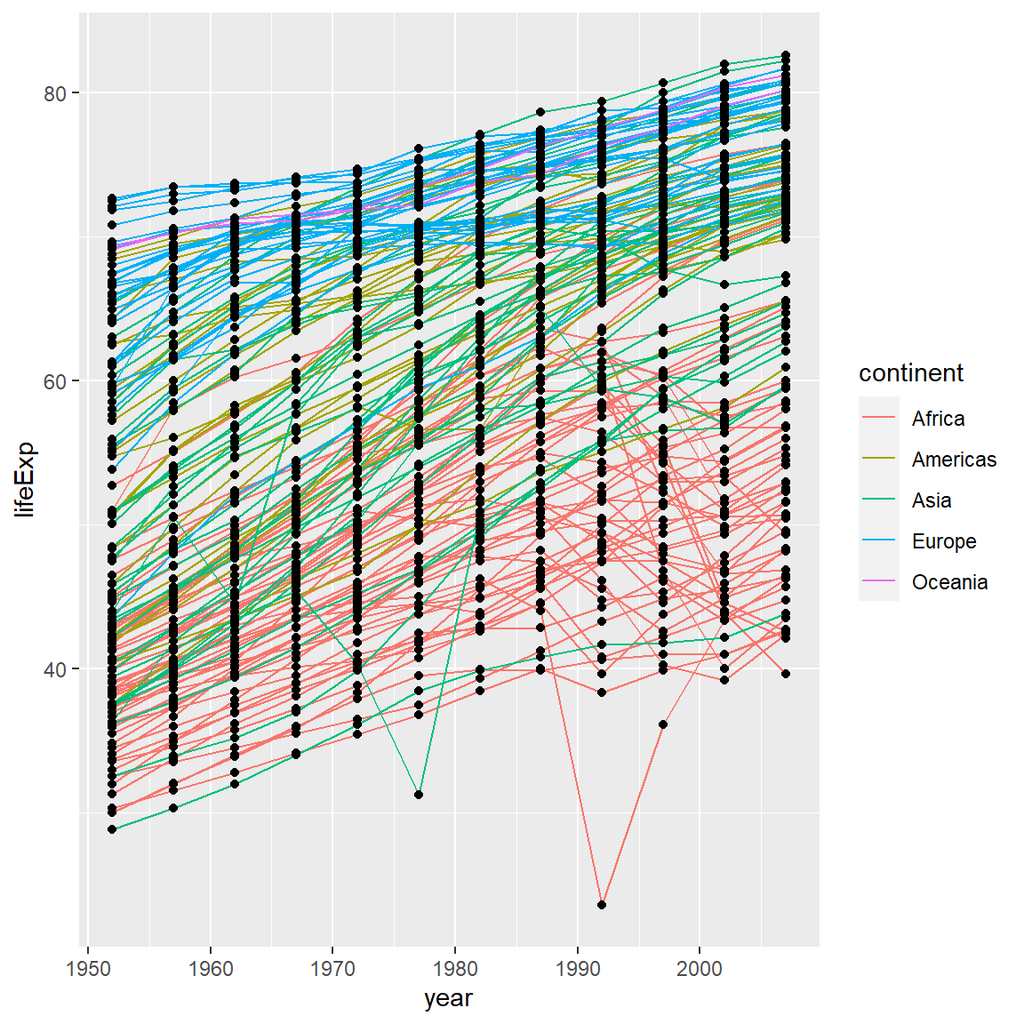

```r
ggplot(data = gapminder,
  mapping = aes(x = year, y = lifeExp, by = country)) +
  geom_line(mapping = aes(color = continent)) +
  geom_point()
```

In this example, the *aesthetic* mapping of **color** has been moved from the global plot options in `ggplot` to the `geom_line` layer so it no longer applies to the points. Now we can clearly see that the points are drawn on top of the lines.

### Challenge 3

Switch the order of the point and line layers from the previous example. What happened?